# hw03_jrhaag2

Jeffery Haag

9/28/2020

## Exercise 1 (Using `lm`)

**(a)**

```r
faithful_model = lm(eruptions ~ waiting, data = faithful)
# plot(eruptions ~ waiting, data = faithful)
# abline(faithfulModel1, lwd = 3)
summary(faithful_model)
```

```
##
## Call:
## lm(formula = eruptions ~ waiting, data = faithful)
##
## Residuals:
##      Min       1Q   Median       3Q      Max
## -1.29917 -0.37689  0.03508  0.34909  1.19329
##
## Coefficients:
##              Estimate Std. Error t value Pr(>|t|)
## (Intercept) -1.874016   0.160143  -11.70   <2e-16 ***
## waiting      0.075628   0.002219   34.09   <2e-16 ***
## ---
## Signif. codes:  0 '***' 0.001 '**' 0.01 '*' 0.05 '.' 0.1 ' ' 1
##
## Residual standard error: 0.4965 on 270 degrees of freedom
## Multiple R-squared:  0.8115, Adjusted R-squared:  0.8108
## F-statistic:  1162 on 1 and 270 DF,  p-value: < 2.2e-16
```

**(b)**

```r
coef(faithful_model)
```

```
## (Intercept)     waiting
## -1.87401599  0.07562795
```

```r
beta_0 = -1.87401599
beta_1_hat = 0.07562795
```

**(c)**

```r
pred80 = beta_1_hat * 80 + beta_0
print(pred80)
```

```
## [1] 4.17622
```

```r
# View(faithful)
```

The prediction is 4.17. I’m not very confident because I looked at the data and there are several data points for 80. Most of them are pretty far off with the closest being 4.3 which is both pretty far off. Most are much bigger with only one smaller than the prediction.

**(d)**

```r
pred120 = beta_1_hat * 120 + beta_0
print(pred120)
```

```
## [1] 7.201338
```

```r
# View(faithful)
```

The prediction is 7.2. Im not very confident because that wait time is much larger than any other data point and I would not expect old faithful eruption time to scale infinitely with wait time. It appears around five is the peak eruption time.

**(e)**

```r
rssFaithful = sum(resid(faithful_model)^2)
rssFaithful
```

```
## [1] 66.56178
```

**(f)**

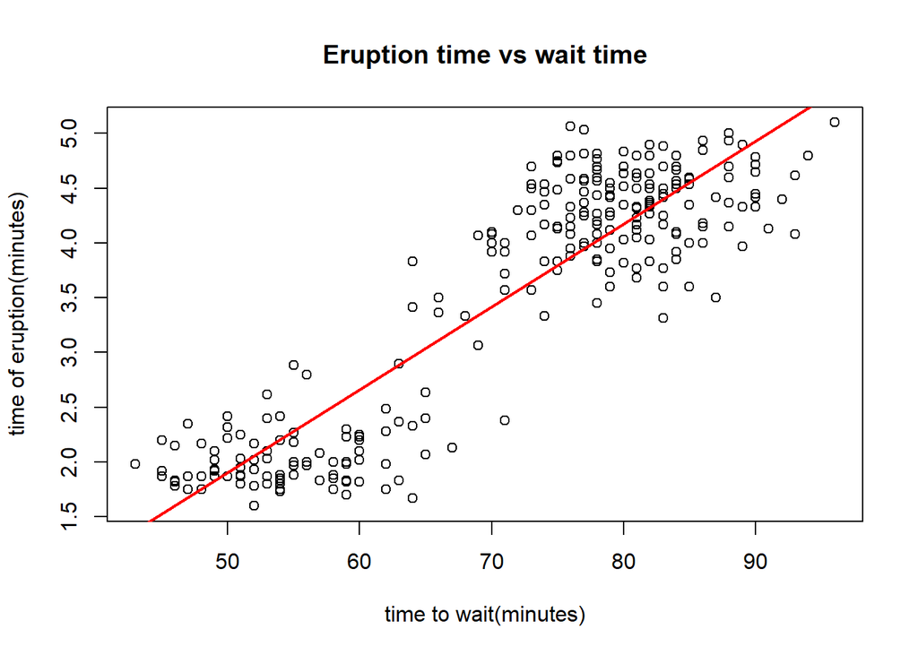

```r
plot(eruptions ~ waiting, data = faithful,
     xlab = "time to wait(minutes)",
     ylab = "time of eruption(minutes)",
     main = "Eruption time vs wait time")
abline(faithful_model, lwd = 2, col = "red")
```

**(g)**

```r
sse = sum((fitted(faithful_model) - mean(faithful$eruptions))^2)
ssr = sum((fitted(faithful_model) - faithful$eruptions)^2)
rsquared = 1 - (ssr/(sse + ssr))

print(rsquared)
```

```
## [1] 0.8114608
```

## Exercise 2 (Writing Functions)

**(a)**

```r
get_sd_est = function(model_resid, mle = FALSE)
{
  if (!mle)
  {
    n = length(model_resid)
    s2_e = sum(model_resid^2) / (n - 2)
    s2_e = sqrt(s2_e)
  }
  else
  {
    sd = (mean(model_resid^2))^0.5

  }
}
```

**(b)**

```r
ansb  = get_sd_est(resid(faithful_model), FALSE)
ansb
```

```
## [1] 0.4965129
```

**(c)**

```r
ansc  = get_sd_est(resid(faithful_model), TRUE)
ansc
```

```
## [1] 0.4946842
```

**(d)**

```r
summary(faithful_model)$sigma
```

```
## [1] 0.4965129
```

## Exercise 3 (Simulating SLR)

**(a)**

```r
birthday = 19991008
set.seed(birthday)

x = runif(n = 50, 0, 10)

sim_slr = function(x, beta_0 = 3, beta_1 = -7, sigma = 2) {
  n = length(x)
  epsilon = rnorm(n, mean = 0, sd = sigma)
  y = beta_0 + beta_1 * x + epsilon
  data.frame(predictor = x, response = y)
}


data_sim = sim_slr(x)
```

**(b)**

```r
fitModel = lm(response ~ predictor, data = data_sim)
# plot(eruptions ~ waiting, data = faithful)
# abline(faithfulModel1, lwd = 3)
coef(fitModel)
```

```
## (Intercept)   predictor
##    2.871557   -6.980457
```

Pretty close to what I would expect with intercept of 2.87 and predictor of -6.98. I would think maybe a little bit closer considering 50 is a pretty large set.

**(c)**

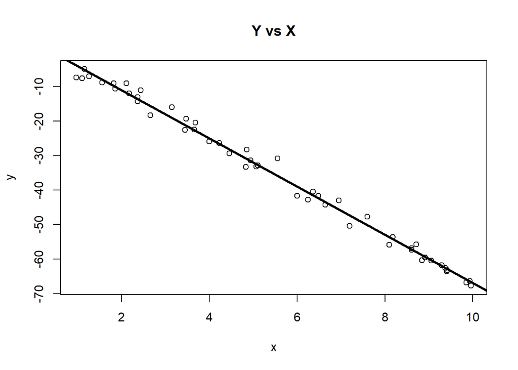

```r
plot(response ~ predictor, data = data_sim,
     xlab = "x",
     ylab = "y",
     main = "Y vs X")
abline(fitModel, lwd = 3)
```

**(d)**

```r
beta_hat_1 = rep(0, 2000)

for (i in 0:2000)
{
  data_sim_temp = sim_slr(x)
  fitModel_temp = lm(response ~ predictor, data = data_sim_temp)
  beta_hat_1[i] = coef(fitModel_temp)[2]

}
```

**(e)**

```r
beta_hat_1_mean = mean(beta_hat_1)
beta_hat_1_sd = sd(beta_hat_1)

beta_hat_1_mean
```

```
## [1] -6.998484
```

```r
beta_hat_1_sd
```

```
## [1] 0.09838986
```

Yes the mean is almost exactly the predictor.

**(f)**

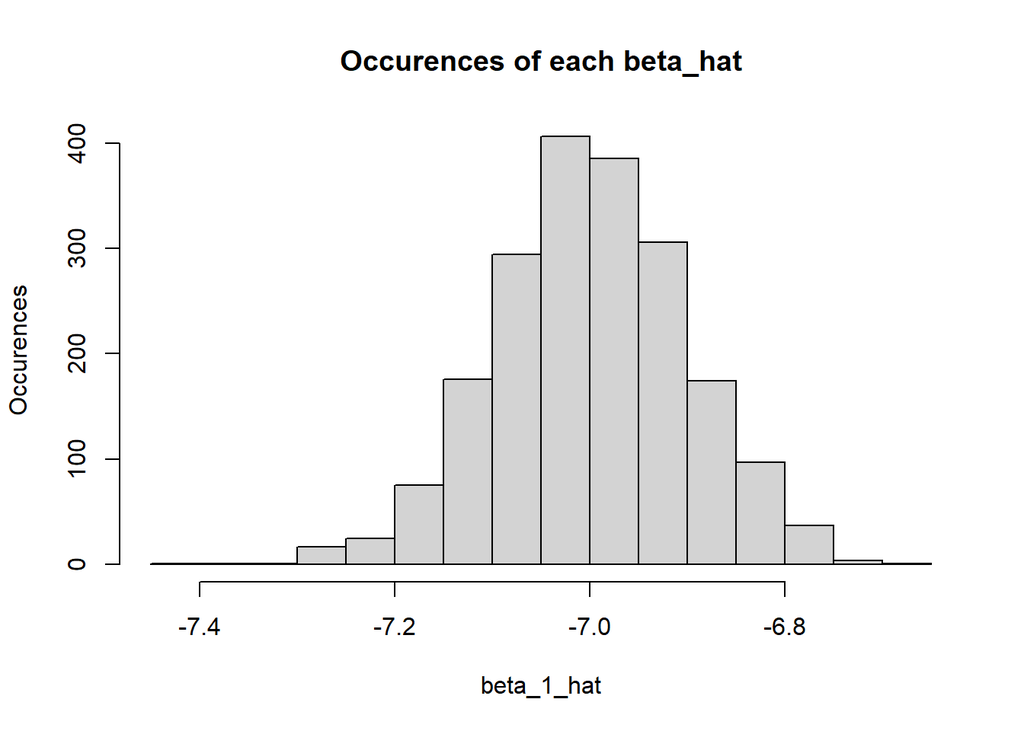

```r
histobaby = hist(beta_hat_1,
     xlab = "beta_1_hat",
     ylab = "Occurences",
     main = "Occurences of each beta_hat")
```

## Exercise 4 (Be a Skeptic)

**(a)**

```r
birthday = 19991008
set.seed(birthday)

x = runif(n = 25, 0, 10)

sim_slr_4 = function(x, beta_0 = 10, beta_1 = 0, sigma = 1) {
  n = length(x)
  epsilon = rnorm(n, mean = 0, sd = sigma)
  y = beta_0 + beta_1 * x + epsilon
  data.frame(predictor = x, response = y)
}


data_sim_4 = sim_slr_4(x)

beta_hat_1 = rep(0, 1500)

for (i in 0:2000)
{
  data_sim_temp = sim_slr_4(x)
  fitModel_temp = lm(response ~ predictor, data = data_sim_temp)
  beta_hat_1[i] = coef(fitModel_temp)[2]

}
```

**(b)**

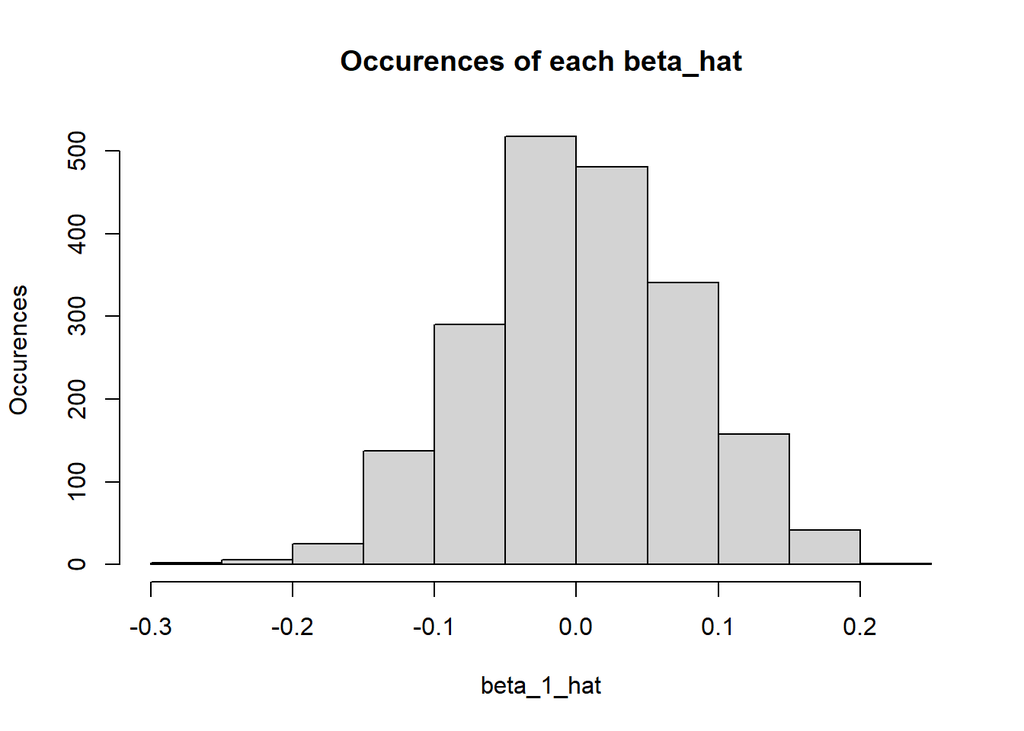

```r
histobaby = hist(beta_hat_1,
     xlab = "beta_1_hat",
     ylab = "Occurences",
     main = "Occurences of each beta_hat")
```

It looks pretty normal, about what I would expect for random simulation

**(c)**

```r
skeptic = read.csv("skeptic.csv")

fitLine = lm(response ~ predictor, data = skeptic)
coef(fitLine)
```

```
## (Intercept)   predictor
##   10.397085    0.154081
```

```r
beta_hat_1_4c = coef(fitLine)[2]
beta_hat_1_4c
```

```
## predictor
##  0.154081
```

**(d)**

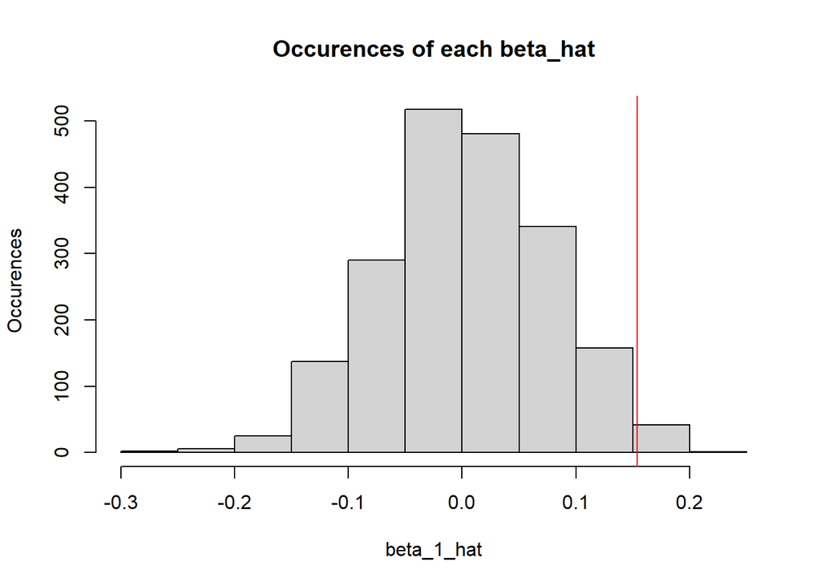

```r
histobaby2 = hist(beta_hat_1,
     xlab = "beta_1_hat",
     ylab = "Occurences",
     main = "Occurences of each beta_hat")

abline(v = beta_hat_1_4c, col = "red")
```

**(e)**

```r
prop = length(which(beta_hat_1 > beta_hat_1_4c))
prop/length(beta_hat_1)
```

```
## [1] 0.0195
```

```r
prop*2/length(beta_hat_1)
```

```
## [1] 0.039
```

**(f)**

No I do not, 2% is pretty incredible rare and as we did before even if its two sided, it still passes the 0.05 test and we can reject the null(Null being that its randomly generated).

## Exercise 5 (Comparing Models)

**(a)**

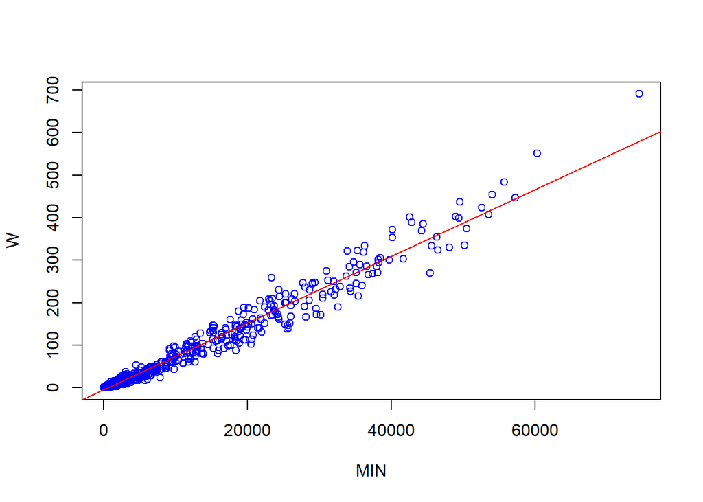

```r
nhl = read.csv("goalies.csv")

rmse2 = function(y)
{
  n = length(y)
  ans = resid(y)^2
  ans = sum(ans)/n
  ans = sqrt(ans)
  return(ans)
}
plot(W ~ MIN, data = nhl, col = "blue")
fit5a = lm(W ~ MIN, data = nhl)
abline(fit5a, col = "red")
```

```r
rmse2(fit5a)
```

```
## [1] 124.1036
```

**(b)**

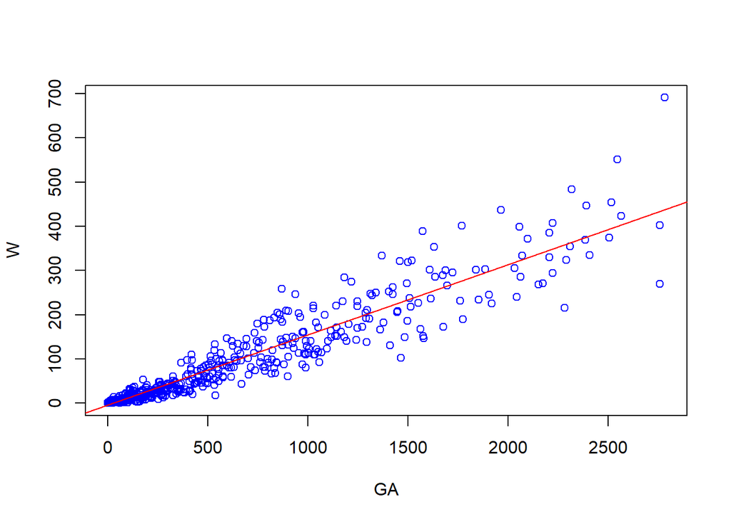

```r
plot(W ~ GA, data = nhl, col = "blue")
fit5b = lm(W ~ GA, data = nhl)
abline(fit5b, col = "red")
```

```r
rmse2(fit5b)
```

```
## [1] 230.1846
```

**(c)**

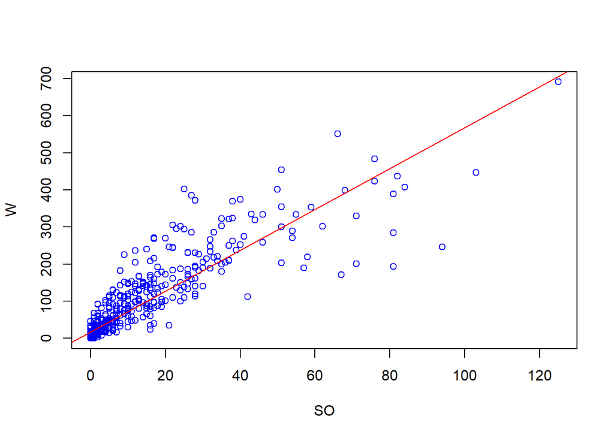

```r
plot(W ~ SO, data = nhl, col = "blue")
fit5c = lm(W ~ SO, data = nhl)
abline(fit5c, col = "red")
```

```r
rmse2(fit5c)
```

```
## [1] 332.0649
```

The model in A is the best because it has the lowes RMSE and therefore the lowest error in the linear model.